# Panda Basics 101 : DataFrames

DataFrames (DF) : Creation `class pandas.DataFrame(data=None, index=None, columns=None, dtype=None, copy=False)`

Two-dimensional size-mutable, potentially heterogeneous tabular data structure with labeled axes (rows and columns). Arithmetic operations align on both row and column labels. Can be thought of as a dict-like container for Series objects. The primary pandas data structure.

```python
#basic imports
import pandas as pd
import numpy  as np
```

## Create DF From List

```python
df = pd.DataFrame([1,2,3,4,5])
df
```

|  | 0 |
| --- | --- |
| 0 | 1 |
| 1 | 2 |
| 2 | 3 |
| 3 | 4 |
| 4 | 5 |

## Create DF From List of Lists

```python
df = pd.DataFrame([[1,2,3,4,5],[10,20,30,40,50], [100,120,130,140,150]])
df
```

|  | 0 | 1 | 2 | 3 | 4 |
| --- | --- | --- | --- | --- | --- |
| 0 | 1 | 2 | 3 | 4 | 5 |
| 1 | 10 | 20 | 30 | 40 | 50 |
| 2 | 100 | 120 | 130 | 140 | 150 |

```python
# provide column labels- must be enough
df = pd.DataFrame([[1,2,3,4,5],[10,20,30,40,50],
                   [100,120,130,140,150]],
                    columns=list("ABCDE"))
df
```

|  | A | B | C | D | E |
| --- | --- | --- | --- | --- | --- |
| 0 | 1 | 2 | 3 | 4 | 5 |
| 1 | 10 | 20 | 30 | 40 | 50 |
| 2 | 100 | 120 | 130 | 140 | 150 |

## Create DF From Dict

```python
#keys = column names  - if val = array, must be same size
df = pd.DataFrame( {"foo": [1,2,3,4], "bar":[9,8,7,6], 'baz':[12,13,14,15] } )
df
```

|  | bar | baz | foo |
| --- | --- | --- | --- |
| 0 | 9 | 12 | 1 |
| 1 | 8 | 13 | 2 |
| 2 | 7 | 14 | 3 |
| 3 | 6 | 15 | 4 |

## Create DF using random decimals and integers (good for experimenting)

```python
df = pd.DataFrame(np.random.randn(5, 4), columns=list('ABCD'))
df
```

|  | A | B | C | D |
| --- | --- | --- | --- | --- |
| 0 | 0.054598 | 0.759245 | -0.220424 | -1.807465 |
| 1 | -1.344629 | 2.760914 | -0.648946 | -1.462125 |
| 2 | -0.374244 | 0.214160 | 0.756628 | 0.079623 |
| 3 | -1.501553 | 1.281096 | -0.766744 | -0.143265 |
| 4 | 0.131592 | -1.380821 | -0.271043 | 1.025389 |

## Generate Random Integers using: randint(low,hi,size=(rows,cols))

```python
df = pd.DataFrame(np.random.randint(low=0, high=10, size=(5, 5)),
                  columns=['a', 'b', 'c', 'd', 'e'])
df
```

|  | a | b | c | d | e |
| --- | --- | --- | --- | --- | --- |
| 0 | 8 | 4 | 8 | 1 | 1 |
| 1 | 2 | 3 | 9 | 8 | 8 |
| 2 | 9 | 6 | 2 | 8 | 3 |
| 3 | 6 | 1 | 8 | 4 | 0 |
| 4 | 7 | 4 | 8 | 3 | 2 |

## Create DF From CSV File

```python
df = pd.read_csv('worldcup.csv')
df
```

|  | WorldCup | year | location | first | second | third | fourth | goalsScored | matchesPlayed | attendance |
| --- | --- | --- | --- | --- | --- | --- | --- | --- | --- | --- |
| 0 | wc1930 | 1930 | Uruguay | Uruguay | Argentina | USA | Yugoslavia | 70 | 18 | 590549 |
| 1 | wc1934 | 1934 | Italy | Italy | Czechoslovakia | Germany | Austria | 70 | 17 | 363000 |
| 2 | wc1938 | 1938 | France | Italy | Hungary | Brazil | Sweden | 84 | 18 | 375000 |
| 3 | wc1950 | 1950 | Brazil | Uruguay | Brazil | Sweden | Spain | 88 | 22 | 1045246 |
| 4 | wc1954 | 1954 | Switzerland | GermanyFR | Hungary | Austria | Uruguay | 14 | 26 | 768607 |
| 5 | wc1958 | 1958 | Sweden | Brazil | Sweden | France | GermanyFR | 126 | 35 | 819810 |
| 6 | wc1962 | 1962 | Chile | Brazil | Czechoslovakia | Chile | Yugoslavia | 89 | 32 | 893172 |
| 7 | wc1966 | 1966 | England | England | GermanyFR | Portugal | Soviet_Union | 89 | 32 | 1563135 |
| 8 | wc1970 | 1970 | Mexico | Brazil | Italy | GermanyFR | Uruguay | 95 | 32 | 1603975 |
| 9 | wc1974 | 1974 | Germany | GermanyFR | Netherlands | Poland | Brazil | 97 | 38 | 1865753 |
| 10 | wc1978 | 1978 | Argentina | Argentina | Netherlands | Brazil | Italy | 102 | 38 | 1545791 |
| 11 | wc1982 | 1982 | Spain | Italy | GermanyFR | Poland | France | 146 | 52 | 2109723 |
| 12 | wc1986 | 1986 | Mexico | Argentina | GermanyFR | France | Belgium | 132 | 52 | 2394031 |
| 13 | wc1990 | 1990 | Italy | GermanyFR | Argentina | Italy | England | 115 | 52 | 2516215 |
| 14 | wc1994 | 1994 | USA | Brazil | Italy | Sweden | Bulgaria | 141 | 52 | 3587538 |
| 15 | wc1998 | 1998 | France | France | Brazil | Croatia | Netherlands | 171 | 64 | 2785100 |
| 16 | wc2002 | 2002 | Korea_Japan | Brazil | Germany | Turkey | KoreaRepublic | 161 | 64 | 2705197 |
| 17 | wc2006 | 2006 | Germany | Italy | France | Germany | Portugal | 147 | 64 | 3359439 |
| 18 | wc2010 | 2010 | SouthAfrica | Spain | Netherlands | Germany | Uruguay | 145 | 64 | 3178856 |
| 19 | wc2014 | 2014 | Brazil | Germany | Argentina | Netherlands | Brazil | 171 | 64 | 3386810 |
| 20 | wc2018 | 2018 | Russia | France | Croatia | Belgium | England | 169 | 64 | 3430000 |

# Creating New Cols/Rows

## New Column Creation based on existing column(s)

```python
df['goalsPerMatch'] = df['goalsScored']/df['matchesPlayed']
df
```

|  | WorldCup | year | location | first | second | third | fourth | goalsScored | matchesPlayed | attendance | goalsPerMatch |
| --- | --- | --- | --- | --- | --- | --- | --- | --- | --- | --- | --- |
| 0 | wc1930 | 1930 | Uruguay | Uruguay | Argentina | USA | Yugoslavia | 70 | 18 | 590549 | 3.888889 |
| 1 | wc1934 | 1934 | Italy | Italy | Czechoslovakia | Germany | Austria | 70 | 17 | 363000 | 4.117647 |
| 2 | wc1938 | 1938 | France | Italy | Hungary | Brazil | Sweden | 84 | 18 | 375000 | 4.666667 |
| 3 | wc1950 | 1950 | Brazil | Uruguay | Brazil | Sweden | Spain | 88 | 22 | 1045246 | 4.000000 |
| 4 | wc1954 | 1954 | Switzerland | GermanyFR | Hungary | Austria | Uruguay | 14 | 26 | 768607 | 0.538462 |
| 5 | wc1958 | 1958 | Sweden | Brazil | Sweden | France | GermanyFR | 126 | 35 | 819810 | 3.600000 |
| 6 | wc1962 | 1962 | Chile | Brazil | Czechoslovakia | Chile | Yugoslavia | 89 | 32 | 893172 | 2.781250 |
| 7 | wc1966 | 1966 | England | England | GermanyFR | Portugal | Soviet_Union | 89 | 32 | 1563135 | 2.781250 |
| 8 | wc1970 | 1970 | Mexico | Brazil | Italy | GermanyFR | Uruguay | 95 | 32 | 1603975 | 2.968750 |
| 9 | wc1974 | 1974 | Germany | GermanyFR | Netherlands | Poland | Brazil | 97 | 38 | 1865753 | 2.552632 |
| 10 | wc1978 | 1978 | Argentina | Argentina | Netherlands | Brazil | Italy | 102 | 38 | 1545791 | 2.684211 |
| 11 | wc1982 | 1982 | Spain | Italy | GermanyFR | Poland | France | 146 | 52 | 2109723 | 2.807692 |
| 12 | wc1986 | 1986 | Mexico | Argentina | GermanyFR | France | Belgium | 132 | 52 | 2394031 | 2.538462 |
| 13 | wc1990 | 1990 | Italy | GermanyFR | Argentina | Italy | England | 115 | 52 | 2516215 | 2.211538 |
| 14 | wc1994 | 1994 | USA | Brazil | Italy | Sweden | Bulgaria | 141 | 52 | 3587538 | 2.711538 |
| 15 | wc1998 | 1998 | France | France | Brazil | Croatia | Netherlands | 171 | 64 | 2785100 | 2.671875 |
| 16 | wc2002 | 2002 | Korea_Japan | Brazil | Germany | Turkey | KoreaRepublic | 161 | 64 | 2705197 | 2.515625 |
| 17 | wc2006 | 2006 | Germany | Italy | France | Germany | Portugal | 147 | 64 | 3359439 | 2.296875 |
| 18 | wc2010 | 2010 | SouthAfrica | Spain | Netherlands | Germany | Uruguay | 145 | 64 | 3178856 | 2.265625 |
| 19 | wc2014 | 2014 | Brazil | Germany | Argentina | Netherlands | Brazil | 171 | 64 | 3386810 | 2.671875 |
| 20 | wc2018 | 2018 | Russia | France | Croatia | Belgium | England | 169 | 64 | 3430000 | 2.640625 |

```python
# sort on this value - creates a copy
df2 = df.sort_values(by='goalsPerMatch', ascending=False)
df2
```

|  | WorldCup | year | location | first | second | third | fourth | goalsScored | matchesPlayed | attendance | goalsPerMatch |
| --- | --- | --- | --- | --- | --- | --- | --- | --- | --- | --- | --- |
| 2 | wc1938 | 1938 | France | Italy | Hungary | Brazil | Sweden | 84 | 18 | 375000 | 4.666667 |
| 1 | wc1934 | 1934 | Italy | Italy | Czechoslovakia | Germany | Austria | 70 | 17 | 363000 | 4.117647 |
| 3 | wc1950 | 1950 | Brazil | Uruguay | Brazil | Sweden | Spain | 88 | 22 | 1045246 | 4.000000 |
| 0 | wc1930 | 1930 | Uruguay | Uruguay | Argentina | USA | Yugoslavia | 70 | 18 | 590549 | 3.888889 |
| 5 | wc1958 | 1958 | Sweden | Brazil | Sweden | France | GermanyFR | 126 | 35 | 819810 | 3.600000 |
| 8 | wc1970 | 1970 | Mexico | Brazil | Italy | GermanyFR | Uruguay | 95 | 32 | 1603975 | 2.968750 |
| 11 | wc1982 | 1982 | Spain | Italy | GermanyFR | Poland | France | 146 | 52 | 2109723 | 2.807692 |
| 6 | wc1962 | 1962 | Chile | Brazil | Czechoslovakia | Chile | Yugoslavia | 89 | 32 | 893172 | 2.781250 |
| 7 | wc1966 | 1966 | England | England | GermanyFR | Portugal | Soviet_Union | 89 | 32 | 1563135 | 2.781250 |
| 14 | wc1994 | 1994 | USA | Brazil | Italy | Sweden | Bulgaria | 141 | 52 | 3587538 | 2.711538 |
| 10 | wc1978 | 1978 | Argentina | Argentina | Netherlands | Brazil | Italy | 102 | 38 | 1545791 | 2.684211 |
| 15 | wc1998 | 1998 | France | France | Brazil | Croatia | Netherlands | 171 | 64 | 2785100 | 2.671875 |
| 19 | wc2014 | 2014 | Brazil | Germany | Argentina | Netherlands | Brazil | 171 | 64 | 3386810 | 2.671875 |
| 20 | wc2018 | 2018 | Russia | France | Croatia | Belgium | England | 169 | 64 | 3430000 | 2.640625 |
| 9 | wc1974 | 1974 | Germany | GermanyFR | Netherlands | Poland | Brazil | 97 | 38 | 1865753 | 2.552632 |
| 12 | wc1986 | 1986 | Mexico | Argentina | GermanyFR | France | Belgium | 132 | 52 | 2394031 | 2.538462 |
| 16 | wc2002 | 2002 | Korea_Japan | Brazil | Germany | Turkey | KoreaRepublic | 161 | 64 | 2705197 | 2.515625 |
| 17 | wc2006 | 2006 | Germany | Italy | France | Germany | Portugal | 147 | 64 | 3359439 | 2.296875 |
| 18 | wc2010 | 2010 | SouthAfrica | Spain | Netherlands | Germany | Uruguay | 145 | 64 | 3178856 | 2.265625 |
| 13 | wc1990 | 1990 | Italy | GermanyFR | Argentina | Italy | England | 115 | 52 | 2516215 | 2.211538 |
| 4 | wc1954 | 1954 | Switzerland | GermanyFR | Hungary | Austria | Uruguay | 14 | 26 | 768607 | 0.538462 |

## Applying functions to DataFrames for each row or column

#### axis confusion

```python
df = pd.DataFrame([[1,1,1,1], [100,200,300,400], [1000,2000,3000,4000]],
                  columns=list('ABCD'))
df
```

|  | A | B | C | D |
| --- | --- | --- | --- | --- |
| 0 | 1 | 1 | 1 | 1 |
| 1 | 100 | 200 | 300 | 400 |
| 2 | 1000 | 2000 | 3000 | 4000 |

```python
#axis=1: All the COLS in each Row
#axis=0: all the ROWS in each COL
def addAll(z):
    #the DF will pass either a row or column (a Series) to this function
    return z.sum()

df2 = df.apply(addAll, axis=1)
print (df2)

#now with axis=0  All ROWS for each COL
#note: the column names are now the row indexes
df3 = df.apply(addAll, axis=0)
print (df3)
```

```
0        4
1     1000
2    10000
dtype: int64
A    1101
B    2201
C    3301
D    4401
dtype: int64
```

## Using Boolean DataFrame to select rows from a DataFrame

Creating a boolean index (a single column of true/false) is useful when you want to select subset of rows from your DataFrame. The strategy is:

- create new DF based on logical operators over the orginal DF
- use the new boolean DF to select only those rows == True

```python
df = pd.DataFrame([ [2,4,6,8], [6,12,44,67], [6,6,6,26], [3,4,5,6]],
                  columns=list("abcd"))
df
```

|  | a | b | c | d |
| --- | --- | --- | --- | --- |
| 0 | 2 | 4 | 6 | 8 |
| 1 | 6 | 12 | 44 | 67 |
| 2 | 6 | 6 | 6 | 26 |
| 3 | 3 | 4 | 5 | 6 |

```python
#simple boolean expession
dbool = df['a'] >= 6
dbool
```

```
0    False
1     True
2     True
3    False
Name: a, dtype: bool
```

```python
#compound boolean condition  - needs parens around each expression
dbool = (df['a'] >= 6) & (df['d'] > df['a']*2)
dbool
```

```
0    False
1     True
2     True
3    False
dtype: bool
```

```python
#apply boolean to original DF
df3 = df[dbool]
df3
```

|  | a | b | c | d |
| --- | --- | --- | --- | --- |
| 1 | 6 | 12 | 44 | 67 |
| 2 | 6 | 6 | 6 | 26 |

# Panda Selection and Slicing from Existing DF

```python
# set up a dataframe
df = pd.DataFrame(np.random.randint(0,100,size=(5, 5)), columns=list('abcde'))
df
```

|  | a | b | c | d | e |
| --- | --- | --- | --- | --- | --- |
| 0 | 15 | 0 | 4 | 83 | 83 |
| 1 | 20 | 57 | 48 | 97 | 31 |
| 2 | 70 | 50 | 29 | 77 | 17 |
| 3 | 34 | 91 | 98 | 35 | 8 |
| 4 | 55 | 43 | 42 | 55 | 99 |

## Select Column or Columns from DF

Index refers to entire column (unlike Python Dict) Note: When selecting a single column or row, a **Series** is returned

### Select Single Column (as Series)

```python
df2 = df['b']
print (df2)
print (type(df2))
```

```
0     0
1    57
2    50
3    91
4    43
Name: b, dtype: int64
<class 'pandas.core.series.Series'>
```

### Select Multiple Columns (as DataFrame) - pass List

```python
df3 = df[ ['a','c','e'] ]
df3
```

|  | a | c | e |
| --- | --- | --- | --- |
| 0 | 15 | 4 | 83 |
| 1 | 20 | 48 | 31 |
| 2 | 70 | 29 | 17 |
| 3 | 34 | 98 | 8 |
| 4 | 55 | 42 | 99 |

### Selecting Single row and single data item using .iloc

```python
# show our DF
df
```

|  | a | b | c | d | e |
| --- | --- | --- | --- | --- | --- |
| 0 | 15 | 0 | 4 | 83 | 83 |
| 1 | 20 | 57 | 48 | 97 | 31 |
| 2 | 70 | 50 | 29 | 77 | 17 |
| 3 | 34 | 91 | 98 | 35 | 8 |
| 4 | 55 | 43 | 42 | 55 | 99 |

### df.iloc expects a numeric index - refers to row

Single integer returns the row

```python
#single index value -> row
df.iloc[2]
```

```
a    70
b    50
c    29
d    77
e    17
Name: 2, dtype: int64
```

### df.iloc with a list of labels -- returns multiple rows

```python
df.iloc[ [1,3,4]]
```

|  | a | b | c | d | e |
| --- | --- | --- | --- | --- | --- |
| 1 | 20 | 57 | 48 | 97 | 31 |
| 3 | 34 | 91 | 98 | 35 | 8 |
| 4 | 55 | 43 | 42 | 55 | 99 |

### Single Data item with .iloc [row,col] -> yields single value

```python
df.iloc[1,2]
```

```
48
```

### Rows and Columns with df.iloc and numeric slice ranges [1:3,2:4]

```python
# use : for all rows
df.iloc[:,2:5]
```

|  | c | d | e |
| --- | --- | --- | --- |
| 0 | 4 | 83 | 83 |
| 1 | 48 | 97 | 31 |
| 2 | 29 | 77 | 17 |
| 3 | 98 | 35 | 8 |
| 4 | 42 | 55 | 99 |

```python
# range over rows and cols with integer indexes
df.iloc[2:4,2:4]
```

|  | c | d |
| --- | --- | --- |
| 2 | 29 | 77 |
| 3 | 98 | 35 |

## Selecting with Labels using df.loc

```python
# show df
df
```

|  | a | b | c | d | e |
| --- | --- | --- | --- | --- | --- |
| 0 | 15 | 0 | 4 | 83 | 83 |
| 1 | 20 | 57 | 48 | 97 | 31 |
| 2 | 70 | 50 | 29 | 77 | 17 |
| 3 | 34 | 91 | 98 | 35 | 8 |
| 4 | 55 | 43 | 42 | 55 | 99 |

```python
# one parameter gives us the entire row. (note: row label is an integer)
# Sanity check:  df[2]      -> column 2 ( if such a label exists)
#                df.loc[2] -> row  with 'label 2' - not the second in series
print (df.loc[2])
```

```
a    70
b    50
c    29
d    77
e    17
Name: 2, dtype: int64
```

```python
# two parameters give single element
df.loc[2,'b']
```

```
50
```

```python
# range of values
df.loc[2:4, 'c':'e']
```

|  | c | d | e |
| --- | --- | --- | --- |
| 2 | 29 | 77 | 17 |
| 3 | 98 | 35 | 8 |
| 4 | 42 | 55 | 99 |

## Select based on column value using in or .isin

Pandas isin() method is used to filter data frames. isin() method helps in selecting rows with having a single or multiple values in a particular column.

```python
df = pd.read_csv('worldcup.csv')
df
```

|  | WorldCup | year | location | first | second | third | fourth | goalsScored | matchesPlayed | attendance |
| --- | --- | --- | --- | --- | --- | --- | --- | --- | --- | --- |
| 0 | wc1930 | 1930 | Uruguay | Uruguay | Argentina | USA | Yugoslavia | 70 | 18 | 590549 |
| 1 | wc1934 | 1934 | Italy | Italy | Czechoslovakia | Germany | Austria | 70 | 17 | 363000 |
| 2 | wc1938 | 1938 | France | Italy | Hungary | Brazil | Sweden | 84 | 18 | 375000 |
| 3 | wc1950 | 1950 | Brazil | Uruguay | Brazil | Sweden | Spain | 88 | 22 | 1045246 |
| 4 | wc1954 | 1954 | Switzerland | GermanyFR | Hungary | Austria | Uruguay | 14 | 26 | 768607 |
| 5 | wc1958 | 1958 | Sweden | Brazil | Sweden | France | GermanyFR | 126 | 35 | 819810 |
| 6 | wc1962 | 1962 | Chile | Brazil | Czechoslovakia | Chile | Yugoslavia | 89 | 32 | 893172 |
| 7 | wc1966 | 1966 | England | England | GermanyFR | Portugal | Soviet_Union | 89 | 32 | 1563135 |
| 8 | wc1970 | 1970 | Mexico | Brazil | Italy | GermanyFR | Uruguay | 95 | 32 | 1603975 |
| 9 | wc1974 | 1974 | Germany | GermanyFR | Netherlands | Poland | Brazil | 97 | 38 | 1865753 |
| 10 | wc1978 | 1978 | Argentina | Argentina | Netherlands | Brazil | Italy | 102 | 38 | 1545791 |
| 11 | wc1982 | 1982 | Spain | Italy | GermanyFR | Poland | France | 146 | 52 | 2109723 |
| 12 | wc1986 | 1986 | Mexico | Argentina | GermanyFR | France | Belgium | 132 | 52 | 2394031 |
| 13 | wc1990 | 1990 | Italy | GermanyFR | Argentina | Italy | England | 115 | 52 | 2516215 |
| 14 | wc1994 | 1994 | USA | Brazil | Italy | Sweden | Bulgaria | 141 | 52 | 3587538 |
| 15 | wc1998 | 1998 | France | France | Brazil | Croatia | Netherlands | 171 | 64 | 2785100 |
| 16 | wc2002 | 2002 | Korea_Japan | Brazil | Germany | Turkey | KoreaRepublic | 161 | 64 | 2705197 |
| 17 | wc2006 | 2006 | Germany | Italy | France | Germany | Portugal | 147 | 64 | 3359439 |
| 18 | wc2010 | 2010 | SouthAfrica | Spain | Netherlands | Germany | Uruguay | 145 | 64 | 3178856 |
| 19 | wc2014 | 2014 | Brazil | Germany | Argentina | Netherlands | Brazil | 171 | 64 | 3386810 |
| 20 | wc2018 | 2018 | Russia | France | Croatia | Belgium | England | 169 | 64 | 3430000 |

```python
#create a bool series
newdf = df['first'].isin(['Brazil'])
#use to filter
df[newdf]
```

|  | WorldCup | year | location | first | second | third | fourth | goalsScored | matchesPlayed | attendance |
| --- | --- | --- | --- | --- | --- | --- | --- | --- | --- | --- |
| 5 | wc1958 | 1958 | Sweden | Brazil | Sweden | France | GermanyFR | 126 | 35 | 819810 |
| 6 | wc1962 | 1962 | Chile | Brazil | Czechoslovakia | Chile | Yugoslavia | 89 | 32 | 893172 |
| 8 | wc1970 | 1970 | Mexico | Brazil | Italy | GermanyFR | Uruguay | 95 | 32 | 1603975 |
| 14 | wc1994 | 1994 | USA | Brazil | Italy | Sweden | Bulgaria | 141 | 52 | 3587538 |
| 16 | wc2002 | 2002 | Korea_Japan | Brazil | Germany | Turkey | KoreaRepublic | 161 | 64 | 2705197 |

```python
newdf = df['first'].isin(['Brazil', 'France'])
#use to filter
df[newdf]
```

|  | WorldCup | year | location | first | second | third | fourth | goalsScored | matchesPlayed | attendance |
| --- | --- | --- | --- | --- | --- | --- | --- | --- | --- | --- |
| 5 | wc1958 | 1958 | Sweden | Brazil | Sweden | France | GermanyFR | 126 | 35 | 819810 |
| 6 | wc1962 | 1962 | Chile | Brazil | Czechoslovakia | Chile | Yugoslavia | 89 | 32 | 893172 |
| 8 | wc1970 | 1970 | Mexico | Brazil | Italy | GermanyFR | Uruguay | 95 | 32 | 1603975 |
| 14 | wc1994 | 1994 | USA | Brazil | Italy | Sweden | Bulgaria | 141 | 52 | 3587538 |
| 15 | wc1998 | 1998 | France | France | Brazil | Croatia | Netherlands | 171 | 64 | 2785100 |
| 16 | wc2002 | 2002 | Korea_Japan | Brazil | Germany | Turkey | KoreaRepublic | 161 | 64 | 2705197 |
| 20 | wc2018 | 2018 | Russia | France | Croatia | Belgium | England | 169 | 64 | 3430000 |

# Get and set single values from DataFrame with .at and .iat

## Get/Set with .at (using labels - not indexes)

```python
# set up a dataframe
df = pd.DataFrame(np.random.randint(0,100,size=(5, 5)), columns=list('abcde'))
df
```

|  | a | b | c | d | e |
| --- | --- | --- | --- | --- | --- |
| 0 | 91 | 3 | 86 | 41 | 20 |
| 1 | 3 | 10 | 49 | 14 | 96 |
| 2 | 96 | 39 | 52 | 76 | 53 |
| 3 | 89 | 24 | 97 | 73 | 6 |
| 4 | 71 | 68 | 1 | 40 | 55 |

```python
# get value
df.at[1,'c']
```

```
49
```

```python
# set value
df.at[1,'c'] = 1002
df
```

|  | a | b | c | d | e |
| --- | --- | --- | --- | --- | --- |
| 0 | 91 | 3 | 86 | 41 | 20 |
| 1 | 3 | 10 | 1002 | 14 | 96 |
| 2 | 96 | 39 | 52 | 76 | 53 |
| 3 | 89 | 24 | 97 | 73 | 6 |
| 4 | 71 | 68 | 1 | 40 | 55 |

## Get/Set with .iat (using integer indexes)

```python
df.iat[3,3]
```

```
73
```

```python
df.iat[3,3] = 3333
df
```

|  | a | b | c | d | e |
| --- | --- | --- | --- | --- | --- |
| 0 | 91 | 3 | 86 | 41 | 20 |
| 1 | 3 | 10 | 1002 | 14 | 96 |
| 2 | 96 | 39 | 52 | 76 | 53 |
| 3 | 89 | 24 | 97 | 3333 | 6 |
| 4 | 71 | 68 | 1 | 40 | 55 |

# Sorting

```python
#set up
df = pd.DataFrame({
  'col1' : ['A', 'A', 'B', np.nan, 'D', 'C'],
  'col2' : [2, 1, 9, 8, 7, 4],
  'col3': [0, 1, 9, 4, 2, 3],
 })
df
```

|  | col1 | col2 | col3 |
| --- | --- | --- | --- |
| 0 | A | 2 | 0 |
| 1 | A | 1 | 1 |
| 2 | B | 9 | 9 |
| 3 | NaN | 8 | 4 |
| 4 | D | 7 | 2 |
| 5 | C | 4 | 3 |

```python
df.sort_values(by=['col1'])
```

|  | col1 | col2 | col3 |
| --- | --- | --- | --- |
| 0 | A | 2 | 0 |
| 1 | A | 1 | 1 |
| 2 | B | 9 | 9 |
| 5 | C | 4 | 3 |
| 4 | D | 7 | 2 |
| 3 | NaN | 8 | 4 |

```python
#sort multiple columns
df.sort_values(by=['col1', 'col2'])
```

|  | col1 | col2 | col3 |
| --- | --- | --- | --- |
| 1 | A | 1 | 1 |
| 0 | A | 2 | 0 |
| 2 | B | 9 | 9 |
| 5 | C | 4 | 3 |
| 4 | D | 7 | 2 |
| 3 | NaN | 8 | 4 |

```python
#sort multiple columns -  DESCENDING
df.sort_values(by=['col1', 'col2'], ascending=False)
```

|  | col1 | col2 | col3 |
| --- | --- | --- | --- |
| 4 | D | 7 | 2 |
| 5 | C | 4 | 3 |
| 2 | B | 9 | 9 |
| 0 | A | 2 | 0 |
| 1 | A | 1 | 1 |
| 3 | NaN | 8 | 4 |

```python
# Put NAs first
df.sort_values(by=['col1', 'col2'], ascending=False, na_position='first')
```

|  | col1 | col2 | col3 |
| --- | --- | --- | --- |
| 3 | NaN | 8 | 4 |
| 4 | D | 7 | 2 |
| 5 | C | 4 | 3 |
| 2 | B | 9 | 9 |
| 0 | A | 2 | 0 |
| 1 | A | 1 | 1 |

# Dropping rows and cols with Unknown NaN values

`DataFrame.dropna(axis=0, how='any', thresh=None, subset=None, inplace=False)`¶

```python
#drop rows with NaN
df.dropna()
```

|  | col1 | col2 | col3 |
| --- | --- | --- | --- |
| 0 | A | 2 | 0 |
| 1 | A | 1 | 1 |
| 2 | B | 9 | 9 |
| 4 | D | 7 | 2 |
| 5 | C | 4 | 3 |

```python
#drop columns
df.dropna(axis=1)
```

|  | col2 | col3 |
| --- | --- | --- |
| 0 | 2 | 0 |
| 1 | 1 | 1 |
| 2 | 9 | 9 |
| 3 | 8 | 4 |
| 4 | 7 | 2 |
| 5 | 4 | 3 |

# GroupBy

When using groupby you get an 'Object' with methods you can use

```python
# Create dataframe from dict: default is keys are column headers
raw_data = {'regiment': ['Nighthawks', 'Nighthawks', 'Nighthawks', 'Nighthawks', 'Dragoons', 'Dragoons', 'Dragoons', 'Dragoons', 'Scouts', 'Scouts', 'Scouts', 'Scouts'],
        'company': ['1st', '1st', '2nd', '2nd', '1st', '1st', '2nd', '2nd','1st', '1st', '2nd', '2nd'],
        'name': ['Miller', 'Jacobson', 'Ali', 'Milner', 'Cooze', 'Jacon', 'Ryaner', 'Sone', 'Sloan', 'Piger', 'Riani', 'Ali'],
        'preTestScore': [4, 24, 31, 2, 3, 4, 24, 31, 2, 3, 2, 3],
        'postTestScore': [22, 94, 57, 62, 70, 25, 94, 57, 62, 70, 62, 70]}
df = pd.DataFrame(raw_data, columns = ['regiment', 'company', 'name', 'preTestScore', 'postTestScore'])
df
```

|  | regiment | company | name | preTestScore | postTestScore |
| --- | --- | --- | --- | --- | --- |
| 0 | Nighthawks | 1st | Miller | 4 | 22 |
| 1 | Nighthawks | 1st | Jacobson | 24 | 94 |
| 2 | Nighthawks | 2nd | Ali | 31 | 57 |
| 3 | Nighthawks | 2nd | Milner | 2 | 62 |
| 4 | Dragoons | 1st | Cooze | 3 | 70 |
| 5 | Dragoons | 1st | Jacon | 4 | 25 |
| 6 | Dragoons | 2nd | Ryaner | 24 | 94 |
| 7 | Dragoons | 2nd | Sone | 31 | 57 |
| 8 | Scouts | 1st | Sloan | 2 | 62 |
| 9 | Scouts | 1st | Piger | 3 | 70 |
| 10 | Scouts | 2nd | Riani | 2 | 62 |
| 11 | Scouts | 2nd | Ali | 3 | 70 |

```python
# Create a groupby variable that groups our DataFrame by regiment
groupby_regiment = df.groupby(['regiment'])
```

```python
print(type(df.groupby(['regiment'])))
```

```
<class 'pandas.core.groupby.DataFrameGroupBy'>
```

```python
print(groupby_regiment)
```

```
<pandas.core.groupby.DataFrameGroupBy object at 0x7f9aa00d5e48>
```

## Get size of your Groups

```python
groupby_regiment.size()
```

```
regiment
Dragoons      4
Nighthawks    4
Scouts        4
dtype: int64
```

## Compute sums and mean of groups : use .sum() and .mean()

```python
groupby_regiment.mean()
```

| regiment | preTestScore | postTestScore |
| --- | --- | --- |
| Dragoons | 15.50 | 61.50 |
| Nighthawks | 15.25 | 58.75 |
| Scouts | 2.50 | 66.00 |

### add_prefix('string') when you sum() or mean() over columns

```python
groupby_regiment.mean().add_prefix('mean_')
```

| regiment | mean_preTestScore | mean_postTestScore |
| --- | --- | --- |
| Dragoons | 15.50 | 61.50 |
| Nighthawks | 15.25 | 58.75 |
| Scouts | 2.50 | 66.00 |

## Iterating over Groups

When iterating you can get the name of the group and a dataframe for the group

```python
for name, group in groupby_regiment:
    print ("Group name = ", name)
    print (group)
```

```
Group name =  Dragoons
   regiment company    name  preTestScore  postTestScore
4  Dragoons     1st   Cooze             3             70
5  Dragoons     1st   Jacon             4             25
6  Dragoons     2nd  Ryaner            24             94
7  Dragoons     2nd    Sone            31             57
Group name =  Nighthawks
     regiment company      name  preTestScore  postTestScore
0  Nighthawks     1st    Miller             4             22
1  Nighthawks     1st  Jacobson            24             94
2  Nighthawks     2nd       Ali            31             57
3  Nighthawks     2nd    Milner             2             62
Group name =  Scouts
   regiment company   name  preTestScore  postTestScore
8    Scouts     1st  Sloan             2             62
9    Scouts     1st  Piger             3             70
10   Scouts     2nd  Riani             2             62
11   Scouts     2nd    Ali             3             70
```

# Ploting

Easy to plot one column vs another Include '%matplotlib inline' to get Jupyter to plot

pandas vs matplotlib

Under the hood, pandas plots graphs with the matplotlib library. This is usually pretty convenient since it allows you to just .plot your graphs, but since matplotlib is kind of a train wreck pandas inherits that confusion. Which .plot do I use?

When you use .plot on a dataframe, you sometimes pass things to it and sometimes you don’t.

```
.plot plots the index against every column
.plot(x='col1') plots against a single specific column
.plot(x='col1', y='col2') plots one specific column against another specific column
```

```python
import matplotlib.pyplot as plt
%matplotlib inline
#load data
df = pd.read_csv('worldcup.csv')
df.head()
```

|  | WorldCup | year | location | first | second | third | fourth | goalsScored | matchesPlayed | attendance |
| --- | --- | --- | --- | --- | --- | --- | --- | --- | --- | --- |
| 0 | wc1930 | 1930 | Uruguay | Uruguay | Argentina | USA | Yugoslavia | 70 | 18 | 590549 |
| 1 | wc1934 | 1934 | Italy | Italy | Czechoslovakia | Germany | Austria | 70 | 17 | 363000 |
| 2 | wc1938 | 1938 | France | Italy | Hungary | Brazil | Sweden | 84 | 18 | 375000 |
| 3 | wc1950 | 1950 | Brazil | Uruguay | Brazil | Sweden | Spain | 88 | 22 | 1045246 |
| 4 | wc1954 | 1954 | Switzerland | GermanyFR | Hungary | Austria | Uruguay | 14 | 26 | 768607 |

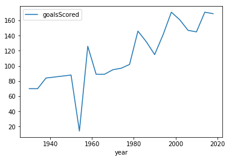

```python
df.plot(y='goalsScored', x='year')
```

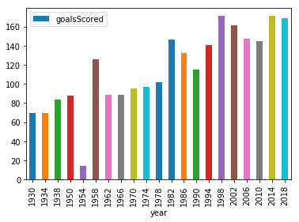

```python
df.plot(y='goalsScored', x='year', kind='bar')
```

### Groupby and plots

Let's look at worldcup and get a plot of goals scored by winning teams

```python
df.groupby('first')['goalsScored'].mean()
```

```
first
Argentina    117.000000
Brazil       122.400000
England       89.000000
France       170.000000
Germany      171.000000
GermanyFR     75.333333
Italy        111.750000
Spain        145.000000
Uruguay       79.000000
Name: goalsScored, dtype: float64
```

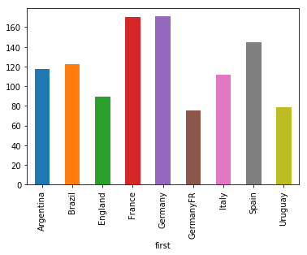

```python
# now add plot to that
df.groupby('first')['goalsScored'].mean().plot(kind='bar')
```

# pandas.DataFrame.to_json

DataFrame.to_json(path_or_buf=None, orient=None, date_format=None, double_precision=10, force_ascii=True, date_unit='ms', default_handler=None, lines=False, compression=None, index=True)

- Convert the object to a JSON string.
- orient defaults to 'columns' : for rows use 'index'
- Note NaN’s and None will be converted to null and datetime objects will be converted to UNIX timestamps.

```python
#set up
df = pd.DataFrame(np.random.randint(low=0, high=20, size=(5, 5)),
                  columns=['a', 'b', 'c', 'd', 'e'], index=['r1','r2','r3','r4','r5']
                )
print (df)
```

```
     a   b   c   d   e
r1  13   3   2   1   1
r2  14   5   3  19  14
r3   3   9   8   5  11
r4  18  16   1  15   2
r5  16  17  16   8  17
```

## Create JSON from columns (default)

```python
s = df.to_json()
print (s)
```

```
{"a":{"r1":13,"r2":14,"r3":3,"r4":18,"r5":16},"b":{"r1":3,"r2":5,"r3":9,"r4":16,"r5":17},"c":{"r1":2,"r2":3,"r3":8,"r4":1,"r5":16},"d":{"r1":1,"r2":19,"r3":5,"r4":15,"r5":8},"e":{"r1":1,"r2":14,"r3":11,"r4":2,"r5":17}}
```

## Create JSON from rows using orient='index'

```python
s = df.to_json(orient='index')
print (s)
```

```
{"r1":{"a":13,"b":3,"c":2,"d":1,"e":1},"r2":{"a":14,"b":5,"c":3,"d":19,"e":14},"r3":{"a":3,"b":9,"c":8,"d":5,"e":11},"r4":{"a":18,"b":16,"c":1,"d":15,"e":2},"r5":{"a":16,"b":17,"c":16,"d":8,"e":17}}
```

```python
new_df = pd.dataframe({'A':[1,2], 'B':[3,4]})
new_df
```

[output not shown]